# Homework10

Carolyn Hanrahan

2023-04-05

# Question 1

Using a for loop, write a function to calculate the number of zeroes in a numeric vector. Before entering the loop, set up a counter variable counter <- 0. Inside the loop, add 1 to counter each time you have a zero in the vector. Finally, use return(counter) for the output.

# if statement within a for loop

```r
z <-c(-2,0,0,1,2,3,5)

counter <- 0

for(i in 1:length(z)) {
  if(z[i] == 0) {counter<-counter + 1}
   }
```

# Question 2

Use subsetting instead of a loop to rewrite the function as a single line of code.

Below is a failed example of me attempting this problem. This answer technically works but is not general enough to run new vectors through.

```r
x <- c(0,0,2,3,1,2)
counter2 <- 0

#counter2 <- if(x[1]|x[2]|x[3]|x[4]|x[5]|x[6]==0){counter2<-counter2+1}
```

Below is a more generalized way of subsetting:

```r
y <- c(0,0,2,1,2,1,2,1) #random vector

counter2 <-sum(y==0)
```

# Question 3

Write a function that takes as input two integers representing the number of rows and columns in a matrix. The output is a matrix of these dimensions in which each element is the product of the row number x the column number.

```r
row <- 2
col <- 2

#######################################
# FUNCTION: make matrix
# packages: none
# purpose: create a new matrix (see output)
# input: number of rows and columns
# output: matrix of these dimensions in which each element is the product of the row number times the column number
#--------------------------------------
makematrix <- function(row, col) {

  m <- matrix(nrow=row,ncol=col)

  for(i in 1:row){

    for(j in 1:col){

       m[i,j] <- i*j

  }

  }

 return(m)
print(m)

}

makematrix(8,2)
```

```
##      [,1] [,2]
## [1,]    1    2
## [2,]    2    4
## [3,]    3    6
## [4,]    4    8
## [5,]    5   10
## [6,]    6   12
## [7,]    7   14
## [8,]    8   16
```

# Question 4:

In the next few lectures, you will learn how to do a randomization test on your data. We will complete some of the steps today to practice calling custom functions within a for loop. Use the code from the March 31st lecture (Randomization Tests) to complete the following steps:

1. Simulate a dataset with 3 groups of data, each group drawn from a distribution with a different mean. The final data frame should have 1 column for group and 1 column for the response variable.

My first attempt(not correct..):

```r
# control <- rnorm(20,mean=5,sd=1)
# treatment1<-rnorm(20,mean=15,sd=2)
# treatment2<-rnorm(20,mean=25,sd=2)
#
# dataframe <- data.frame(control,treatment1,treatment2)
#
# print(dataframe)
#
# pivotdf <- pivot_longer(dataframe,cols=c('treatment1'))
#
# print(pivotdf)
```

Using Nick’s code:

```r
trt_group <- c(rep("Control",4),rep("Treatment1",4),rep("Treatment2",4))
print(trt_group)
```

```
##  [1] "Control"    "Control"    "Control"    "Control"    "Treatment1"
##  [6] "Treatment1" "Treatment1" "Treatment1" "Treatment2" "Treatment2"
## [11] "Treatment2" "Treatment2"
```

```r
z <- c(runif(4) + 1, runif(4) + 10, runif(4)+2)
print(z)
```

```
##  [1]  1.733822  1.067102  1.523785  1.708644 10.851763 10.608208 10.185324
##  [8] 10.063070  2.079424  2.432783  2.716989  2.897427
```

```r
df <- data.frame(trt=trt_group,res=z)
print(df)
```

```
##           trt       res
## 1     Control  1.733822
## 2     Control  1.067102
## 3     Control  1.523785
## 4     Control  1.708644
## 5  Treatment1 10.851763
## 6  Treatment1 10.608208
## 7  Treatment1 10.185324
## 8  Treatment1 10.063070
## 9  Treatment2  2.079424
## 10 Treatment2  2.432783
## 11 Treatment2  2.716989
## 12 Treatment2  2.897427
```

2. Write a custom function that 1) reshuffles the response variable, and 2) calculates the mean of each group in the reshuffled data. Store the means in a vector of length 3.

```r
#######################################
# FUNCTION: re-shuffle
# packages: none
# purpose:
# input:
# output:
#--------------------------------------
shuffle_data <- function(df) {

  df[,2] <- sample(df[,2])


            mean <- df%>%
            group_by(trt) %>%
            summarize(Mean=mean(res))

            return(mean)

            print(mean)

}

shuffle_data(df)
```

```
## # A tibble: 3 × 2
##   trt         Mean
##   <chr>      <dbl>
## 1 Control     6.35
## 2 Treatment1  6.32
## 3 Treatment2  1.80
```

3. Use a for loop to repeat the function in b 100 times. Store the results in a data frame that has 1 column indicating the replicate number and 1 column for each new group mean, for a total of 4 columns.

```r
#dataframe <- data.frame(repNumber=numeric(0),ControlMean=numeric(0),Treatment1Mean=numeric(0),Treatment2Mean=numeric(0))

dataframe<-data.frame(matrix(NA, nrow=100, ncol=4))

colnames(dataframe) <- c('replicateNumber','ControlMean','Treatment1Mean','Treatment2Mean')

print(dataframe)
```

```
##     replicateNumber ControlMean Treatment1Mean Treatment2Mean
## 1                NA          NA             NA             NA
## 2                NA          NA             NA             NA
## 3                NA          NA             NA             NA
## 4                NA          NA             NA             NA
## 5                NA          NA             NA             NA
## 6                NA          NA             NA             NA
## 7                NA          NA             NA             NA
## 8                NA          NA             NA             NA
## 9                NA          NA             NA             NA
## 10               NA          NA             NA             NA
## 11               NA          NA             NA             NA
## 12               NA          NA             NA             NA
## 13               NA          NA             NA             NA
## 14               NA          NA             NA             NA
```

[output cut: 86 more lines]

```r
print(df)
```

```
##           trt       res
## 1     Control  1.733822
## 2     Control  1.067102
## 3     Control  1.523785
## 4     Control  1.708644
## 5  Treatment1 10.851763
## 6  Treatment1 10.608208
## 7  Treatment1 10.185324
## 8  Treatment1 10.063070
## 9  Treatment2  2.079424
## 10 Treatment2  2.432783
## 11 Treatment2  2.716989
## 12 Treatment2  2.897427
```

```r
for(i in 1:100) {
 x<-shuffle_data(df)


   dataframe[i,1] <-i
   dataframe[i,2] <- x[1,2]
   dataframe[i,3] <- x[2,2]
   dataframe[i,4] <- x[3,2]

   }

print(dataframe)
```

```
##     replicateNumber ControlMean Treatment1Mean Treatment2Mean
## 1                 1    6.113842       4.085090       4.268154
## 2                 2    4.274448       4.322432       5.870206
## 3                 3    6.477696       5.848730       2.140660
## 4                 4    4.418060       6.288902       3.760124
## 5                 5    5.906994       4.236666       4.323426
## 6                 6    6.571424       6.134243       1.761419
## 7                 7    3.817900       6.662876       3.986310
## 8                 8    6.168507       6.609206       1.689373
## 9                 9    2.101845       8.499396       3.865845
## 10               10    4.140927       1.981380       8.344779
## 11               11    4.236666       5.892320       4.338100
## 12               12    3.918410       4.366656       6.182020
## 13               13    6.248414       4.186147       4.032525
## 14               14    3.926733       4.214720       6.325632
```

[output cut: 86 more lines]

```r
dataframe$replicateNumber
```

```
##   [1]   1   2   3   4   5   6   7   8   9  10  11  12  13  14  15  16  17  18
##  [19]  19  20  21  22  23  24  25  26  27  28  29  30  31  32  33  34  35  36
##  [37]  37  38  39  40  41  42  43  44  45  46  47  48  49  50  51  52  53  54
##  [55]  55  56  57  58  59  60  61  62  63  64  65  66  67  68  69  70  71  72
##  [73]  73  74  75  76  77  78  79  80  81  82  83  84  85  86  87  88  89  90
##  [91]  91  92  93  94  95  96  97  98  99 100
```

4. Use qplot() to create a histogram of the means for each reshuffled group. Or,if you want a challenge, use ggplot() to overlay all 3 histograms in the same figure. How do the distributions of reshuffled means compare to the original means?

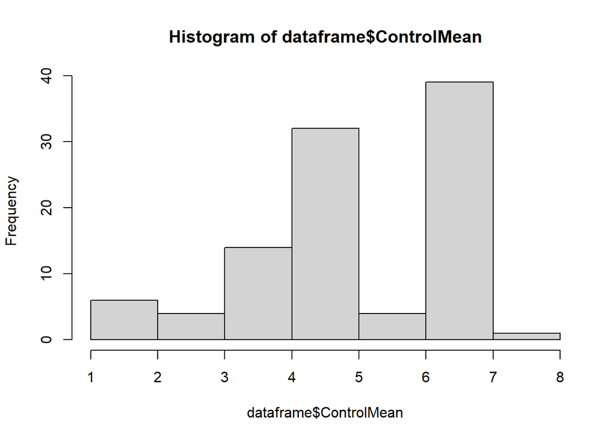

```r
hist(dataframe$ControlMean)
```

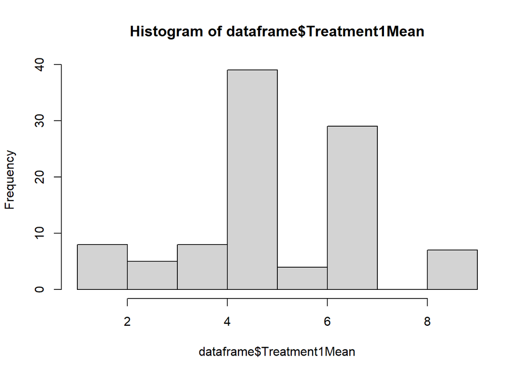

```r
hist(dataframe$Treatment1Mean)
```

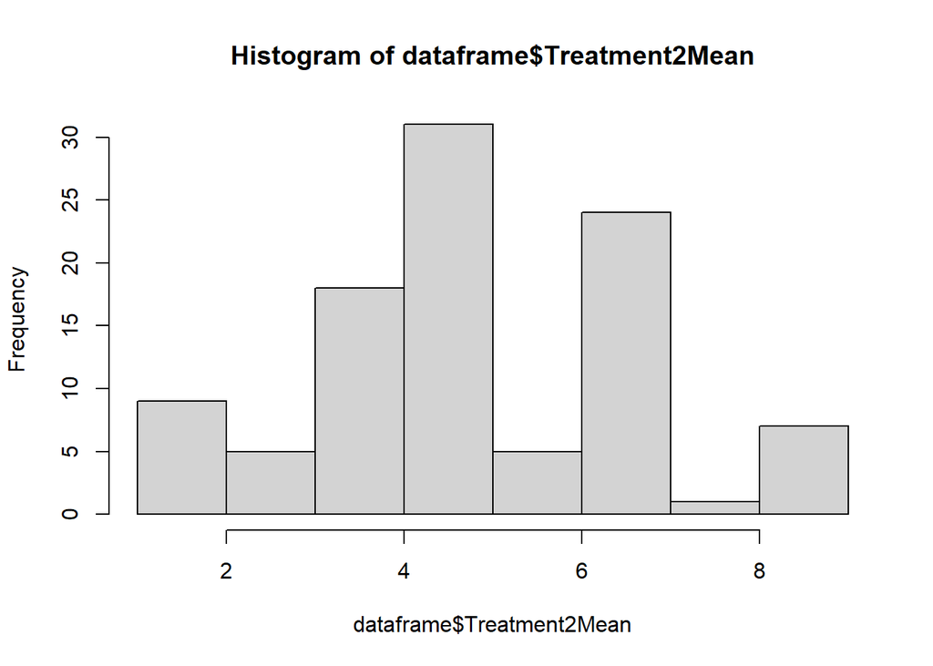

```r
hist(dataframe$Treatment2Mean)
```